# Synapse Clustering: Synapse Exploration

JLP

2016-06-03

[Homepage](http://docs.neurodata.io/synaptome-stats/)  
The formatted source code for this file is [here](https://github.com/neurodata/synaptome-stats/blob/gh-pages/Code/SynapseExploration.Rmd).  
And a [raw version here](https://raw.githubusercontent.com/neurodata/synaptome-stats/gh-pages/Code/SynapseExploration.Rmd).  
Previous work by Youngser Park can be found [here](http://www.cis.jhu.edu/~parky/Synapse/synapse.html).

# 1 Introduction

# 2 Data

Here we read in the data and select a random half of it for exploration.

```r
featFull <- fread("../data/synapsinR_7thA.tif.Pivots.txt.2011Features.txt",showProgress=FALSE)
locFull <- fread("../data/synapsinR_7thA.tif.Pivots.txt",showProgress=FALSE)

### Setting a seed and creating an index vector
### to select half of the data
set.seed(2^10)
half1 <- sample(dim(featFull)[1],dim(featFull)[1]/2)
half2 <- setdiff(1:dim(featFull)[1],half1)

feat <- featFull[half1,]
loc <- locFull[half1,]
dim(feat)
```

```
# [1] 559649    144
```

```r
## Setting the channel names
channel <- c('Synap_1','Synap_2','VGlut1_t1','VGlut1_t2','VGlut2','Vglut3',
              'psd','glur2','nmdar1','nr2b','gad','VGAT',
              'PV','Gephyr','GABAR1','GABABR','CR1','5HT1A',
              'NOS','TH','VACht','Synapo','tubuli','DAPI')

## Setting the channel types
channel.type <- c('ex.pre','ex.pre','ex.pre','ex.pre','ex.pre','in.pre.small',
                  'ex.post','ex.post','ex.post','ex.post','in.pre','in.pre',
                  'in.pre','in.post','in.post','in.post','in.pre.small','other',
                  'ex.post','other','other','ex.post','none','none')

nchannel <- length(channel)
nfeat <- ncol(feat) / nchannel

## Createing factor variables for channel and channel type sorted properly
ffchannel <- (factor(channel.type,
    levels= c("ex.pre","ex.post","in.pre","in.post","in.pre.small","other","none")
    ))
fchannel <- as.numeric(factor(channel.type,
    levels= c("ex.pre","ex.post","in.pre","in.post","in.pre.small","other","none")
    ))
ford <- order(fchannel)


## Setting up colors for channel types
Syncol <- c("#197300","#5ed155","#660000","#cc0000","#ff9933","mediumblue","gold")
ccol <- Syncol[fchannel]

exType <- factor(c(rep("ex",11),rep("in",6),rep("other",7)),ordered=TRUE)
exCol<-exType;levels(exCol) <- c("#197300","#990000","mediumblue");
exCol <- as.character(exCol)

fname <- as.vector(sapply(channel,function(x) paste0(x,paste0("F",0:5))))
names(feat) <- fname
fcol <- rep(ccol, each=6)
mycol <- colorpanel(100, "purple", "black", "green")
mycol2 <- matlab.like(nchannel)
```

## 2.1 Data transformations

```r
f <- lapply(1:6,function(x){seq(x,ncol(feat),by=nfeat)})
featF <- lapply(f,function(x){subset(feat,select=x)})

featF0 <- featF[[1]]
f01e3 <- 1e3*data.table(apply(X=featF0, 2, function(x){((x-min(x))/(max(x)-min(x)))}))

fs <- f01e3

### Taking log_10 on data with 0's removed
ans <- apply(featF0, 1, function(row){ any(row == 0)})

logF0 <- log10(featF0[!ans,])
slogF0 <- logF0[,lapply(.SD,scale, center=TRUE,scale=TRUE)]
```

We now have the following data sets:

- `featF0`: The feature vector looking only at the integrated brightness features.
- `fs`: The feature vector scaled between $[0,1000]$.
- `logF0`: The feature vector, with 0’s removed, then $log_{10}$ is applied.
- `slogF0`: The feature vector, with 0’s removed, then $log_{10}$, then scaled by subtracting the mean and dividing by the sample standard deviation.

# 3 Synapse Exploration

## 3.1 Correlations

```r
tmp <- as.numeric(table(fchannel))
cmatf0 <- cor(featF0)
```

### 3.1.1 PCA on the Correlation Matrix

```r
pcaf0 <- prcomp(featF0,scale=TRUE, center=TRUE)
elpcaf0 <- getElbows(pcaf0$sdev, plot=FALSE)
```

```r
K1 <- c(2)  ## The set of K's.
#km1 <- kmeans(pcaf0$x[,1:elpcaf0[2]], centers=K1)
kp1 <- kmpp(fs, k=K1)
```

### 3.1.2 Heat maps:

For the following we manualy choose 2 clusters.

```r
## Formatting data for heatmap
aggp <- aggregate(fs,by=list(lab=kp1$cluster),FUN=mean)
aggp <- as.matrix(aggp[,-1])
rownames(aggp) <- clusterFraction(kp1)
ford <- order(fchannel)
```

[output not shown]

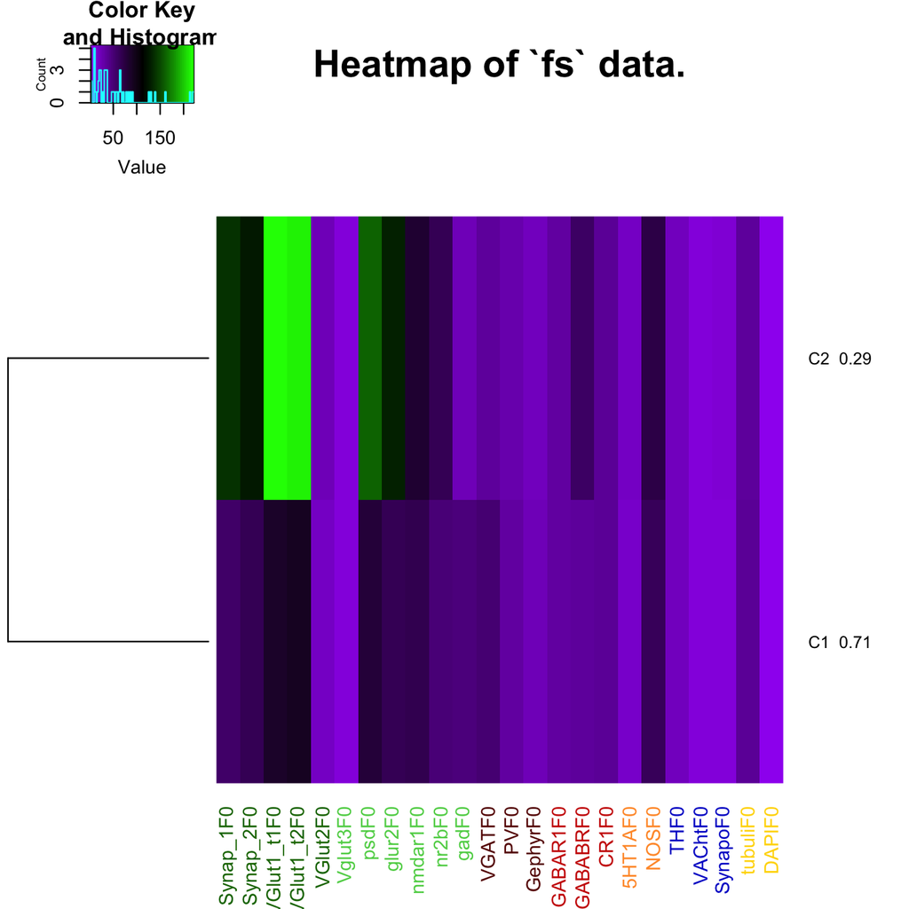

```r
heatmap.2(as.matrix(aggp),dendrogram='row',Colv=NA,trace="none", col=mycol,colCol=ccol[ford],cexRow=0.8, keysize=1.25,symkey=FALSE,symbreaks=FALSE,scale="none", srtCol=90,main="Heatmap of `fs` data.")
```

Percentage of data within cluster is presented on the right side of the heatmap.

```r
set.seed(2^12)
s1 <- sample(dim(loc)[1],2.5e4)
locs1 <- loc[s1,]
kcol <- kp1$cluster[s1]
plot3d(locs1$V1,locs1$V2,locs1$V3,pch='.', col=ifelse(kcol==1,'cyan','black'), alpha=0.75, xlab='x', ylab='y', zlab='z')

subid <- currentSubscene3d()
rglwidget(elementId="plot3dLocations")
```

[interactive chart not shown]